# Reproducible Research: Peer Assessment 1

## Loading and preprocessing the data

```r
library(lubridate)
library(lattice)
activity <- read.csv("activity.csv")
```

“…This device collects data at 5 minute intervals through out the day…” So, we should have 288 intervals per day (288 minutes x 5 = 1440 minutes = 24 hours) and the minimum and maximum value should be 0 and 1435 respectively. Each day has 288 intervals, but the maximum value is not 1435.

```r
rangeInterval <- range(activity$interval)
```

The range is 0, 2355 which it doesnt make sense for our purposes. Lets plot it:

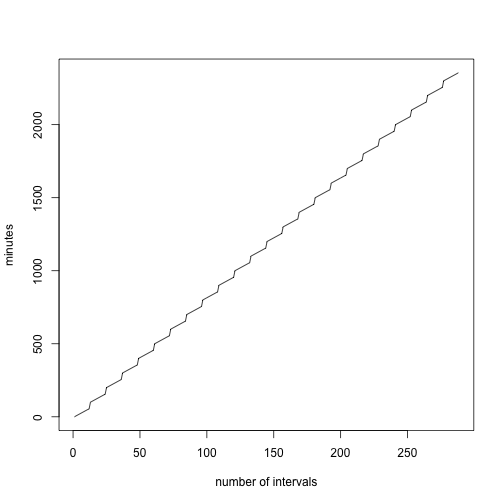

```r
plot(1:288, as.numeric(levels(factor(activity$interval))), type="l", xlab = "number of intervals", ylab = "minutes")
```

There are regular gaps between several pairs of intervals. Lets fix them with new labels from 0 to 1435:

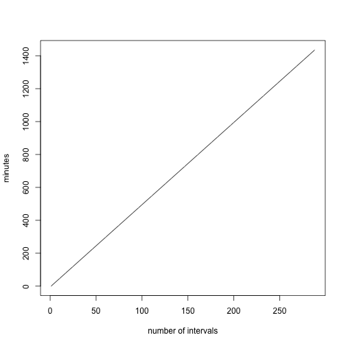

```r
activity$interval <- factor(activity$interval, labels=seq(0, by=5, length=288))
plot(1:288, as.numeric(levels(activity$interval)), type="l", xlab = "number of intervals", ylab = "minutes")
```

## What is mean total number of steps taken per day?

```r
stepsPerDay <- with(activity, tapply(steps, date, sum))
meanStepsPerDay <- mean(stepsPerDay, na.rm=T)
```

The mean total number of steps taken per day is 1.0766 × 10<sup>4</sup>.

```r
medianStepsPerDay <- median(stepsPerDay, na.rm=T)
```

The total median is 10765.

The histogram looks like this:

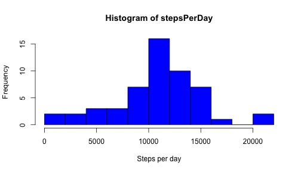

```r
hist(stepsPerDay, col="blue", breaks=10, xlab = "Steps per day")
```

## What is the average daily activity pattern?

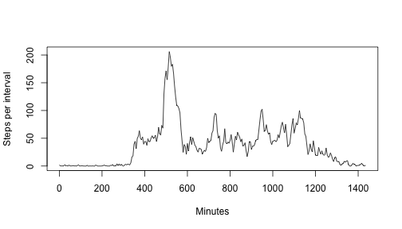

```r
stepsPerInterval <- with(activity, tapply(steps, interval, mean, na.rm=TRUE))
plot(levels(activity$interval), stepsPerInterval, type="l", xlab = "Minutes", ylab ="Steps per interval")
```

```r
maxStepsPerInterval <- max(stepsPerInterval)
intervalOfmaxSteps <- names(stepsPerInterval[stepsPerInterval == maxStepsPerInterval])
timeOfMaxInterval <- format(Sys.Date() + minutes(intervalOfmaxSteps), "%H:%M")
```

The maximum steps per interval is 206.1698 , which corresponds to the interval 515, at 08:35.

## Imputing missing values

I think it is better to fill NAs with the mean of the interval, that we calculated before:

```r
noNAsActivity <- activity
noNAsActivity$steps <- apply(noNAsActivity, 1,
    function (x)
        if (is.na(x["steps"]))
            as.numeric(stepsPerInterval[x["interval"]])
        else
            as.numeric(x["steps"]))
head(noNAsActivity)
```

```
##     steps       date interval
## 1 1.71698 2012-10-01        0
## 2 0.33962 2012-10-01        5
## 3 0.13208 2012-10-01       10
## 4 0.15094 2012-10-01       15
## 5 0.07547 2012-10-01       20
## 6 2.09434 2012-10-01       25
```

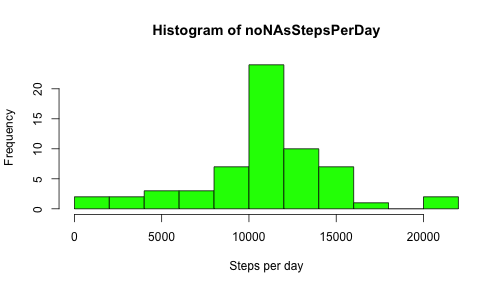

```r
noNAsStepsPerDay <- with(noNAsActivity, tapply(steps, date, sum))
hist(noNAsStepsPerDay, col="green", breaks=10, xlab = "Steps per day")
```

```r
noNAsMean <- mean(noNAsStepsPerDay)
```

The mean is 1.0766 × 10<sup>4</sup>, same as before because we have used the average intervals for fill the NAs

## Are there differences in activity patterns between weekdays and weekends?

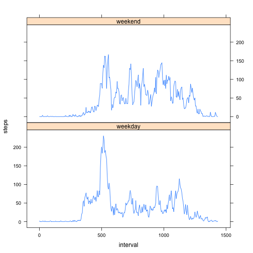

```r
noNAsActivity$weekday <- wday(ymd(noNAsActivity$date), label=TRUE)
noNAsActivity$week <- sapply(noNAsActivity$weekday,
    function (x)
        if (x %in% c("Sat","Sun"))
            "weekend"
        else
            "weekday"
    )
stepsPerIntervalWeekDay <- with(noNAsActivity[noNAsActivity$week == "weekday",],
    tapply(steps, interval, mean))
stepsPerIntervalWeekEnd <- with(noNAsActivity[noNAsActivity$week == "weekend",],
    tapply(steps, interval, mean))

stepsPerInterval <- data.frame(interval = rep(seq(0, by=5, length=288), 2),
    steps = c(stepsPerIntervalWeekDay, stepsPerIntervalWeekEnd),
    week = c(rep("weekday", 288), rep("weekend", 288)))

xyplot(steps~interval | week, data = stepsPerInterval, layout = c(1,2), type="l")
```

So… yes, the are differences between weedays and weekends. He/She looks more active in weekends :)